# assignment2

mgeletka

May 7, 2020

- regression
- regression trees,
- bagging,
- random forest,
- kernel approaches

```r
library(mice)
library(GGally)
library(geosphere)
library(dplyr)
library(VIM)
library(rpart)
library(rattle)
library(foreach)
library(e1071)
library(caret)
library(gbm)
library(party)
library(mboost)
library(plyr)
library(partykit)
library(randomForest)
library(lubridate)
library(caTools)
library(Metrics)
library(kernlab)
dataOriginal <- read.csv("Melbourne_housing_FULL.csv", header = TRUE, na.strings=c("", "NA", "#N/A"))
```

### NA values

Let’s visualize NA values

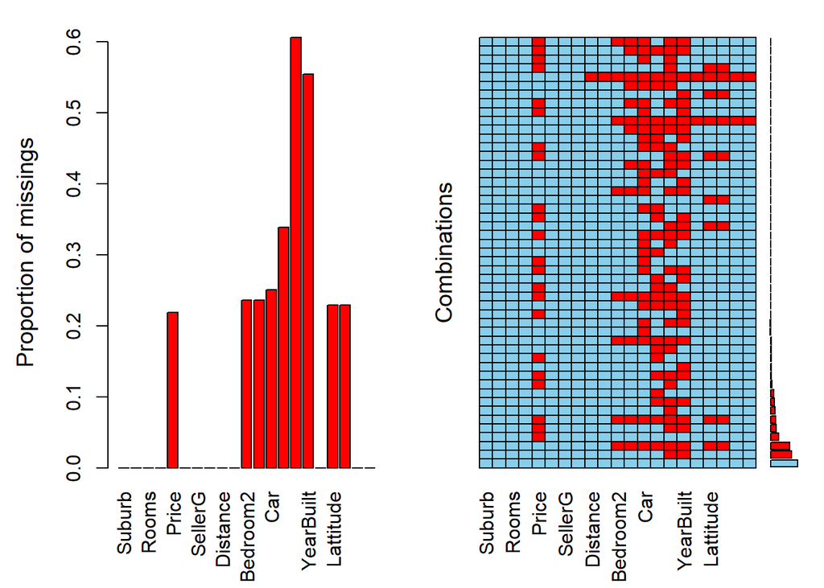

```r
aggr(dataOriginal,delimiter=NULL, plot=TRUE)
```

####Discard NA values of price

```r
dataOriginal <- read.csv("Melbourne_housing_FULL.csv", header = TRUE, na.strings=c("", "NA", "#N/A"))

dataOriginal <- dataOriginal[!is.na(dataOriginal$Price),]
```

####Replacing NA values

```r
set.seed(101)
init = mice(dataOriginal, maxit=0)
dataComplete <- complete(init)
```

We will decide later to use dataComplete or dataOriginal, according to each technique.

#### Logarithmic distribution

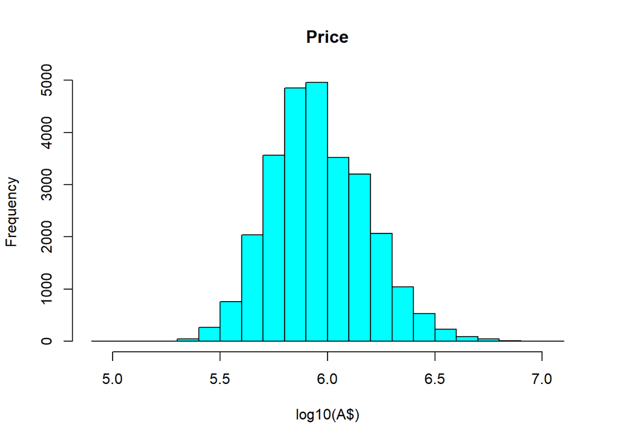

```r
hist(log10(dataOriginal$Price),col=5, main=paste("Price"),xlab="log10(A$)")
```

#### Summary of data

```r
  str(data)
  summary(data)
```

[output not shown]

### Aggregating attributes and deriving new columns

```r
aggregetaData <- function(data) {

  # Add year column and street column
  addresses<-gsub("[[:punct:]]", "", data$Address)
  addresses<-gsub("[[:digit:]]", "", addresses)

  newData<-mutate(data, YearSaled=year(dataOriginal$Date))

  # Add season column
  newData <- mutate(newData, Season=ifelse(month(newData$Date) %in% 3:5, "Spring",ifelse(month(newData$Date) %in% 6:8, "summer", ifelse(month(newData$Date) %in% 9:11, "Autumn","Winter"))))

  # Remove unuseful columns
  newData<-select(newData,-c(Address,Date))

  # Add a column with the distance to the center of the bay
  MelbourneBayCentre <- cbind(144.783832, -38.104275)
  newData <- mutate(newData, DistanceToBayCentre = distGeo(cbind(Longtitude, Lattitude), MelbourneBayCentre)/1000)   #in km

  # Make from string variables factor
  newData$Season <- factor(newData$Season)

  # Add a column with the distance to the airports
  MelbourneAirport<-c( 144.841802,-37.670149)
  AvalonAirport<- c( 144.473152,-38.027377)
  EssendonAirport<- c( 144.902035,-37.726376)
  MoorabbinAirport <- c( 145.100306,-37.979454)
  newData<-mutate(newData,DistanceToAirports = pmin(distGeo(cbind(Longtitude,Lattitude), MelbourneAirport), distGeo(cbind(Longtitude,Lattitude), AvalonAirport), distGeo(cbind(Longtitude,Lattitude), EssendonAirport), distGeo(cbind(Longtitude,Lattitude), MoorabbinAirport))/1000) #in km

   return(newData)
}
data <- aggregetaData(dataOriginal)
dataComplete <- aggregetaData(dataComplete)
```

## Linear regression

### Create the train end test dataset

```r
split = sample.split(dataComplete, SplitRatio = 0.5)
smallDataset = subset(dataComplete, split == TRUE)
split = sample.split(data, SplitRatio = 0.7)
smallDatasetTrain = subset(smallDataset, split == TRUE)
smallDatasetTest = subset(smallDataset, split == FALSE)
```

```r
train.data <- sapply( smallDatasetTrain, as.numeric )
test.data <- sapply(smallDatasetTest, as.numeric)
smallDataset <- sapply(smallDataset, as.numeric)


smallDataset <- data.frame(smallDataset)
test.data <- data.frame(test.data)
train.data <- data.frame(train.data)
```

```r
model <- lm(Price ~., data = train.data)


predictions <- model %>% predict(test.data)
f = data.frame(R2 = R2(predictions,test.data$Price),
           MAE = MAE(predictions, test.data$Price),
           RMSE = RMSE(predictions,test.data$Price))
```

### Cross validation

```r
# Define training control
set.seed(123)
train.control <- trainControl(method = "cv", number = 10)
# Train the model
model <- train(Price ~., data = smallDataset, method = "lm",trControl = train.control)
# Summarize the results
r2.cross = summary(model)$r.squared
rmse.cross = summary(model)$rmse
rmse.cross
```

```r
summary(model)
```

```
##
## Call:
## lm(formula = .outcome ~ ., data = dat)
##
## Residuals:
##      Min       1Q   Median       3Q      Max
## -1982530  -242452   -58470   155018  9225733
##
## Coefficients:
##                       Estimate Std. Error t value Pr(>|t|)
## (Intercept)         -1.320e+08  6.331e+06 -20.843  < 2e-16 ***
## Suburb              -5.112e+02  3.961e+01 -12.904  < 2e-16 ***
## Rooms                2.407e+05  7.068e+03  34.047  < 2e-16 ***
## Type                -2.061e+05  5.880e+03 -35.056  < 2e-16 ***
## Method              -1.973e+03  2.040e+03  -0.967 0.333448
## SellerG              2.252e+01  3.755e+01   0.600 0.548733
## Distance            -4.494e+04  9.119e+02 -49.282  < 2e-16 ***
## Postcode             1.042e+03  4.300e+01  24.228  < 2e-16 ***
## Bedroom2            -1.147e+04  6.205e+03  -1.849 0.064500 .
## Bathroom             1.254e+05  6.569e+03  19.095  < 2e-16 ***
## Car                  3.348e+04  4.209e+03   7.956 1.93e-15 ***
## Landsize             3.533e+00  9.235e-01   3.826 0.000131 ***
## BuildingArea         2.195e+01  6.871e+00   3.195 0.001403 **
## YearBuilt           -1.122e+03  1.088e+02 -10.316  < 2e-16 ***
## CouncilArea         -4.681e+03  4.127e+02 -11.341  < 2e-16 ***
## Lattitude            2.562e+05  1.558e+05   1.644 0.100167
## Longtitude           9.794e+05  7.258e+04  13.494  < 2e-16 ***
## Regionname           2.201e+04  2.289e+03   9.617  < 2e-16 ***
## Propertycount       -1.520e+00  8.945e-01  -1.699 0.089304 .
## YearSaled            1.452e+03  4.708e+02   3.084 0.002047 **
## Season              -6.024e+03  3.588e+03  -1.679 0.093239 .
## DistanceToBayCentre -1.339e+04  1.775e+03  -7.540 5.00e-14 ***
## DistanceToAirports   9.316e+03  7.575e+02  12.299  < 2e-16 ***
## ---
## Signif. codes:  0 '***' 0.001 '**' 0.01 '*' 0.05 '.' 0.1 ' ' 1
##
## Residual standard error: 445100 on 13009 degrees of freedom
## Multiple R-squared:  0.5087, Adjusted R-squared:  0.5078
## F-statistic: 612.2 on 22 and 13009 DF,  p-value: < 2.2e-16
```

### Bagging

```r
length_divisor<-4
iterations<-1000
predictions<-foreach(m=1:iterations,.combine=cbind) %do% {
  training_positions <-  sample(nrow(train.data),size=floor((nrow(train.data)/length_divisor)))
  train_pos<-1:nrow(train.data) %in% training_positions

  lm_fit<-lm(Price~. ,data=train.data)

  predict(lm_fit,newdata=test.data)
}


predictions<-rowMeans(predictions)
error<-sqrt((sum((test.data$Price-predictions)^2)))/nrow(test.data)
difference <- predictions - test.data$Price
bagg.r2 = cor(test.data$Price,predictions)^2
bagg.rmse = sqrt(mean(difference^2))
print(bagg.r2)
```

```
## [1] 0.4870324
```

```r
print(bagg.rmse)
```

```
## [1] 447438.1
```

### Boosting

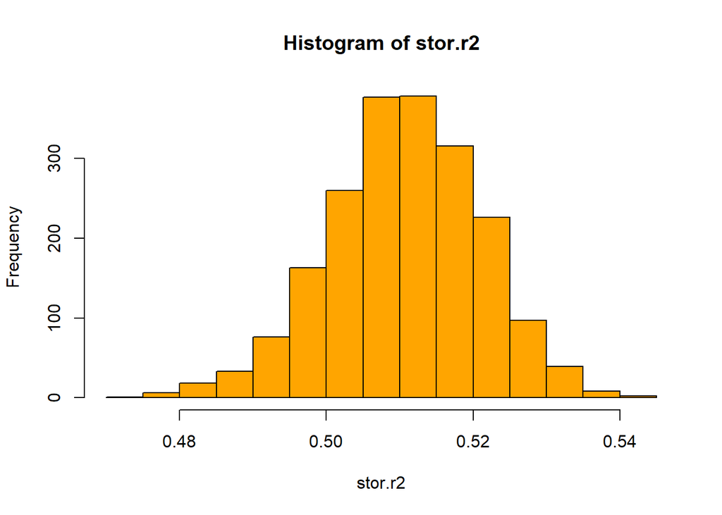

```r
B = 2000
N = length(smallDataset[,1])

stor.r2 = rep(0,B)
stor.rmse = rep(0,B)

for(i in 1:B){
  idx = sample(1:N,N,replace = TRUE)
  newdata = smallDataset[idx,]

  model <- lm(Price~.,data = newdata)

  stor.r2[i] <- summary(model)$r.squared
  stor.rmse[i] <- sqrt(mean(model$residuals^2))

}
hist(stor.r2,col = "orange")
```

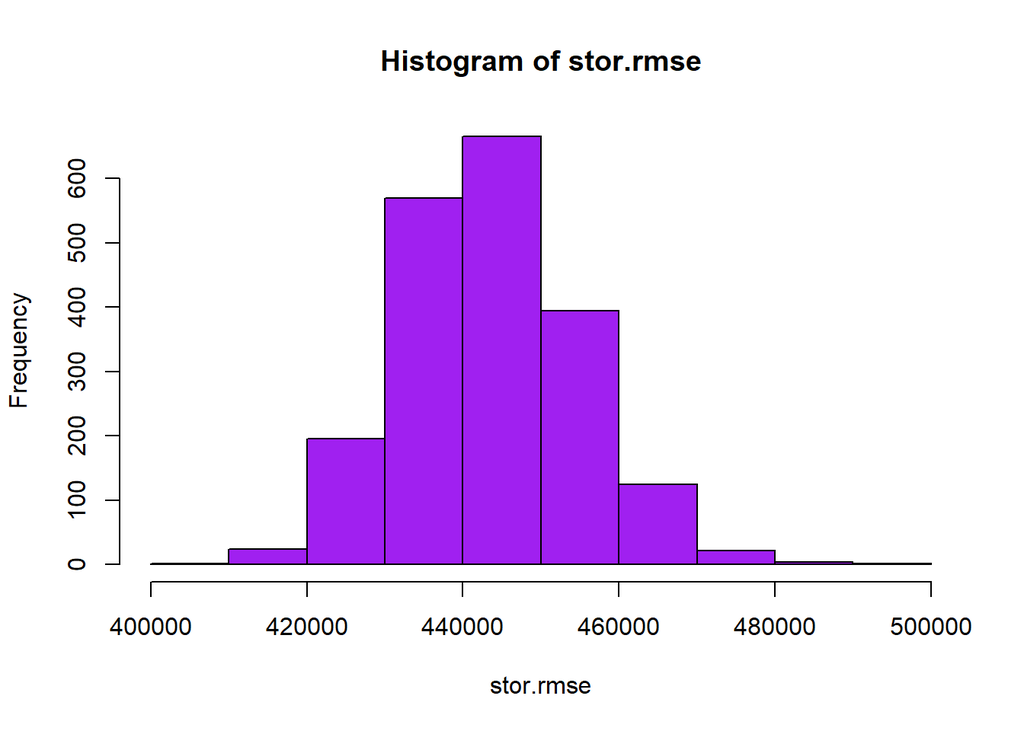

```r
hist(stor.rmse,col = "purple")
```

```r
print(min(stor.rmse))
```

```
## [1] 409904.1
```

```r
print(max(stor.r2))
```

```
## [1] 0.5424989
```

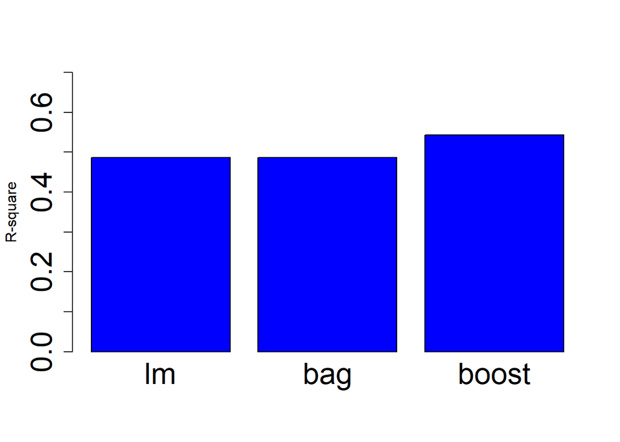

```r
df<-data.frame(Methods=c('lm','bag','boost'),Rsquared=c(f$R2,bagg.r2,max(stor.r2)))
barplot(df$Rsquared,ylab='R-square',names.arg=df$Methods,
cex.names=2,col='blue',cex.axis=2,
ylim=c(0,0.7))
```

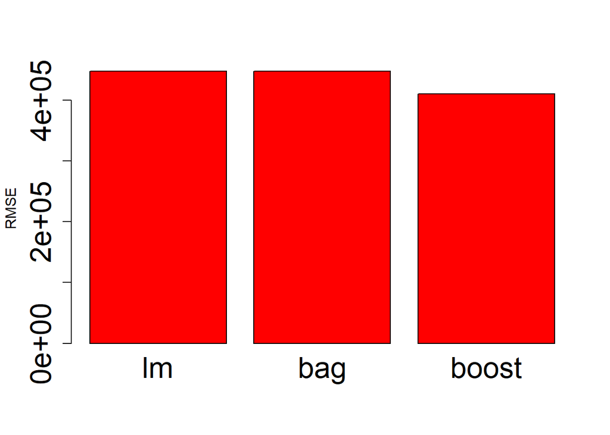

```r
df<-data.frame(Methods=c('lm','bag','boost'),Rsquared=c(f$RMSE,bagg.rmse,min(stor.rmse)))
barplot(df$Rsquared,ylab='RMSE',names.arg=df$Methods,
cex.names=2,col='red',cex.axis=2)
```

in the barplot we can see that the boosted model is the best one.

## Regression trees

Since to compute cross validation on a rpart model we need to not have NA values, we proceed considering the dataset dataComplete.

#### Splitting the dataset into train and test

```r
train.indexes <- sample(1:nrow(dataComplete),0.75*nrow(dataComplete))
data.train <- dataComplete[train.indexes,]
data.test <- dataComplete[-train.indexes,]
ytrain <- data.train[,"Price"]
ytest <- data.test[,"Price"]
```

### Training the tree regression model with different cp value

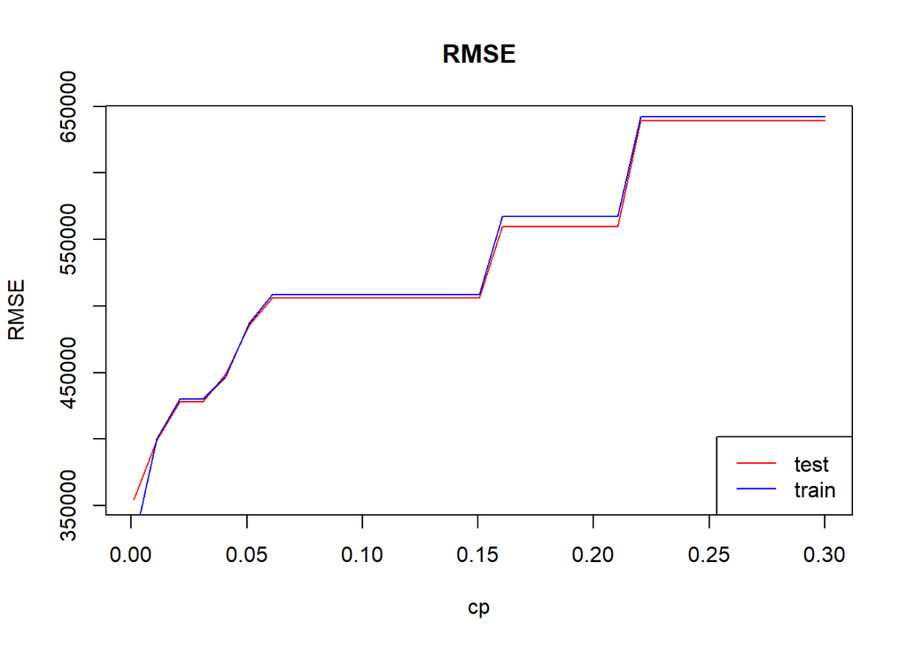

```r
cp_vect<-seq(0.001,0.3,(0.3-0.001)/30)
RMSE.tree.test=numeric(length(cp_vect))
RMSE.tree.train=numeric(length(cp_vect))
Rsquared.tree=numeric(length(cp_vect))
for (i in seq(1:length(cp_vect))){
  model.tree=rpart(Price ~ . ,data = data.train,cp=cp_vect[i])
  pred.tree.test <- predict(model.tree,newdata=data.test)
  pred.tree.train <- predict(model.tree,newdata=data.train)
  RMSE.tree.test[i] <- sqrt(mean((pred.tree.test-ytest)^2))
  RMSE.tree.train[i] <- sqrt(mean((pred.tree.train-ytrain)^2))
  Rsquared.tree[i] <- 1 - sum((pred.tree.test-ytest)^2)/sum((ytest-mean(ytest))^2)
}
# plot RMSE vs cp
plot(cp_vect,RMSE.tree.test,type="l",col="red",xlab="cp",ylab="RMSE",main="RMSE")
lines(cp_vect,RMSE.tree.train,col="blue")
legend("bottomright",lty=1,col=c("red","blue"),legend = c("test ", "train "))
```

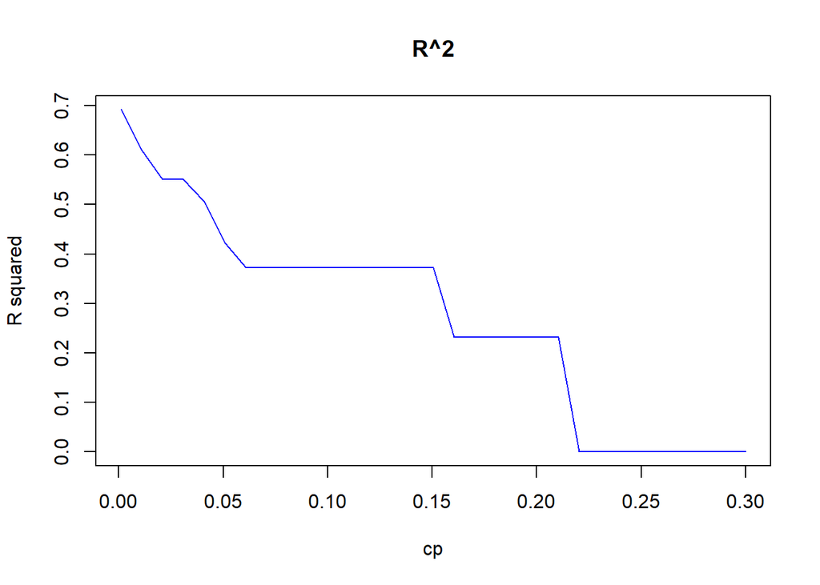

```r
# plot Rsquared vs cp
plot(cp_vect,Rsquared.tree,type="l",col="blue", xlab="cp",ylab="R squared", main="R^2")
```

We can see that the smaller cp is, the better is the model (lower RMSE and higher Rsquared).

Let’s apply 10-fold cross validation to confirm it.

We had to remove the columns of Suburbs and Sellers to run a later part of the code (bagging and boosting), so we remove those columns from here in order to make a comparison between the different techniques. The information of Suburbs is already contained in the latitude and longitude, and we saw that Sellers are not that significative in our model.

```r
train_control <- trainControl(method="cv", number=10)
evaltree <- train(Price~., data=dataComplete[,-c(1,6)], trControl=train_control, method="rpart",tuneLength = 10)
evaltree$bestTune
```

```
##            cp
## 1 0.008340634
```

### Training the tree regression model with different max.depth values

Now we want to see how different values of max.depth affect our tree regression model.

```r
# learn a tree regression model with different values of max.depth, and the best cp value found before
depth_vect <- seq (1,30,1)
RMSE.tree.test=numeric(length(depth_vect))
RMSE.tree.train=numeric(length(depth_vect))
Rsquared.tree=numeric(length(depth_vect))
for (i in seq(1:length(depth_vect))){
  model.tree=rpart(Price ~ . ,data = data.train,maxdepth=depth_vect[i],cp=evaltree$bestTune)
  pred.tree.test <- predict(model.tree,newdata=data.test)
  pred.tree.train <- predict(model.tree,newdata=data.train)
  RMSE.tree.test[i] <- sqrt(mean((pred.tree.test-ytest)^2))
  RMSE.tree.train[i] <- sqrt(mean((pred.tree.train-ytrain)^2))
  Rsquared.tree[i] <- 1 - sum((pred.tree.test-ytest)^2)/sum((ytest-mean(ytest))^2)
}
```

[figure not shown]

```r
# plot RMSE
plot(depth_vect,RMSE.tree.test,type="l",col="red",xlab="cp",ylab="RMSE",main="RMSE", ylim=c(350000, 575000))
lines(depth_vect,RMSE.tree.train,col="blue")
legend("bottomright",lty=1,col=c("red","blue"),legend = c("test ", "train "))
```

[figure not shown]

```r
# plot Rsquared
plot(depth_vect,Rsquared.tree,type="l",col="blue", xlab="cp",ylab="R squared", main="R^2")
```

We can see that for a depth greater than 5 RMSE and R squared stay constant, so it’s fine to keep the default value max.depth=30.

### Final standard tree regression model

This is the final model obtained through cross validation on the tuning parameter cp.

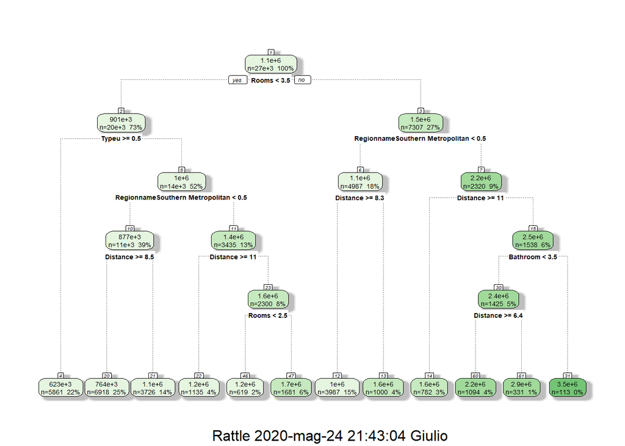

```r
fancyRpartPlot(evaltree$finalModel)
```

```r
#RMSE and Rsquared of our final model
rmse1 <- evaltree$results$RMSE[1]
rs1 <- evaltree$results$Rsquared[1]
```

Now we want to see if we can improve the model with bagging and boosting.

### Bagging

```r
evaltreebag <- train(Price~., data=dataComplete[,-c(1,6)], trControl=train_control, method="treebag") #it takes like 5 minutes to run
# R squared
rs2<-evaltreebag$results$Rsquared
# RMSE
rmse2<-evaltreebag$results$RMSE
```

### Boosting

```r
evaltreeboost <- train(Price~., data=dataComplete[,-c(1,6)], trControl=train_control, method="blackboost") #takes 35/40 minutes to run D:
# R squared
rs3<-evaltreeboost$results$Rsquared[9]
# RMSE
rmse3<-evaltreeboost$results$RMSE[9]
```

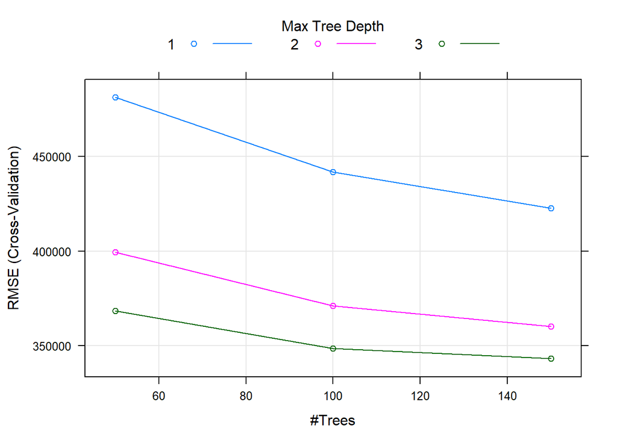

```r
# Let's see with Cross Validation what are the best tuning paramenters for boosting
plot(evaltreeboost)
```

```r
evaltreeboost$bestTune
```

```
##   mstop maxdepth
## 9   150        3
```

### Final comparison

Now we can compare regression trees, bagged regression trees, boosted regression trees.

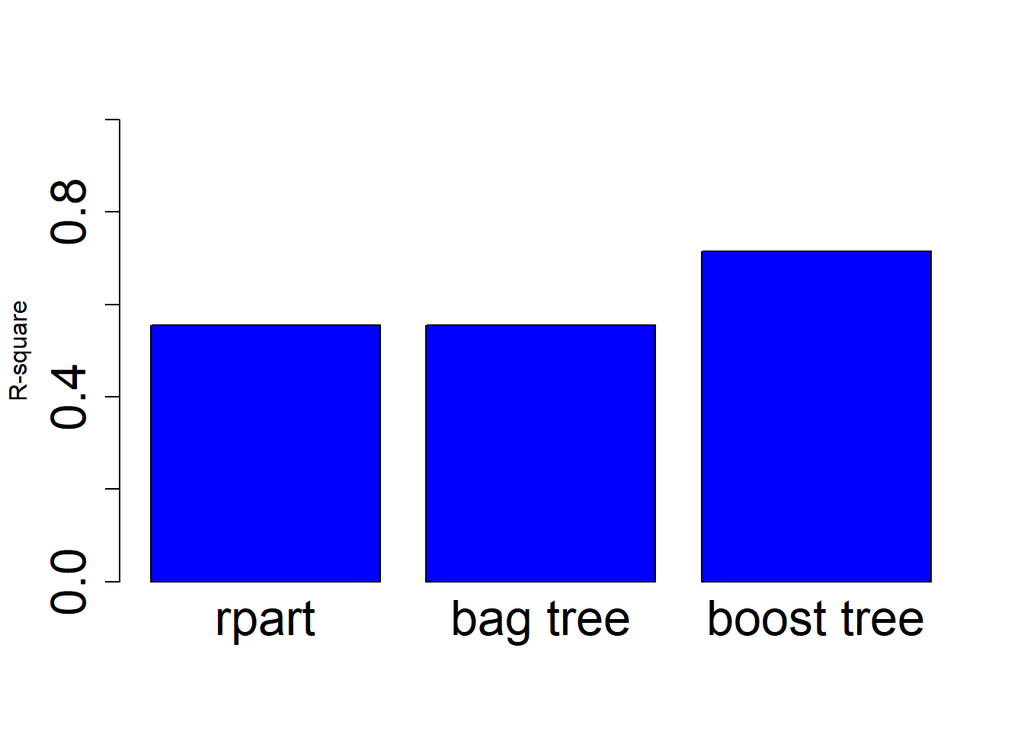

```r
df<-data.frame(Methods=c('rpart','bag tree','boost tree'),Rsquared=c(rs1,rs2,rs3))
barplot(df$Rsquared,ylab='R-square',names.arg=df$Methods,
cex.names=2,col='blue',cex.axis=2,
ylim=c(0,1))
```

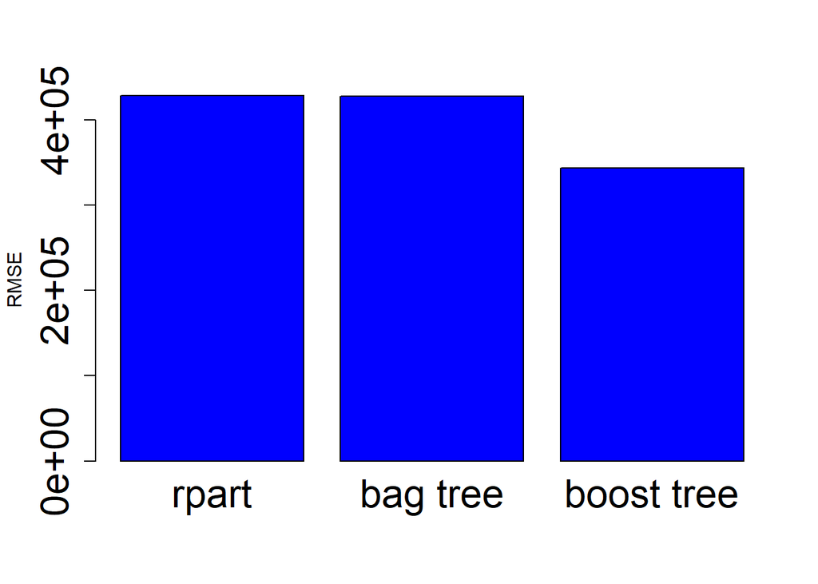

```r
df<-data.frame(Methods=c('rpart','bag tree','boost tree'),Rsquared=c(rmse1,rmse2,rmse3))
barplot(df$Rsquared,ylab='RMSE',names.arg=df$Methods,
cex.names=2,col='blue',cex.axis=2)
```

We can see that the boosted model is the best one, with the highest R squared and the smallest RMSE.

##Support Vector Machine (SVM)

```r
set.seed(123)
split = sample.split(dataComplete, SplitRatio = 0.01)
smallDataset = subset(dataComplete, split == TRUE)
split = sample.split(data, SplitRatio = 0.7)
smallDatasetTrain = subset(smallDataset, split == TRUE)
smallDatasetTest = subset(smallDataset, split == FALSE)
traindDfWithoutPrice <- smallDatasetTrain[-4]
testDfWithoutPrice <- smallDatasetTest[-4]
```

Although the method ksvm does not fail when given NA value, internally is omitting them and learning anything from them. So with SVM, we used the complete dataset created by data imputation.

Now we tried a couple of SVM with a different model on all columns of the data. We perform 10-fold cross-validation to see the training error and cross-validation error of each model.

#### Linear kernel classifier of the classifier

```r
linearSVMclassifier <- ksvm(Price ~ ., smallDatasetTrain, kernel="vanilladot", cross = 10, scaled = TRUE)
linearSVMclassifier
```

```
## Support Vector Machine object of class "ksvm"
##
## SV type: eps-svr  (regression)
##  parameter : epsilon = 0.1  cost C = 1
##
## Linear (vanilla) kernel function.
##
## Number of Support Vectors : 660
##
## Objective Function Value : -164.8678
## Training error : 0.309278
## Cross validation error : 216213804157
```

```r
predictedPrice = predict(linearSVMclassifier, testDfWithoutPrice)
error = postResample(smallDatasetTest$Price, predictedPrice)
error
```

```
##         RMSE     Rsquared          MAE
## 3.649181e+05 5.739404e-01 2.515227e+05
```

#### Anova kernel classifier of the classifier

```r
anovaSVMclassifier <- ksvm(Price ~ ., smallDatasetTrain, kernel="anovadot", cross = 10, scaled = TRUE)
anovaSVMclassifier
```

```
## Support Vector Machine object of class "ksvm"
##
## SV type: eps-svr  (regression)
##  parameter : epsilon = 0.1  cost C = 1
##
## Anova RBF kernel function.
##  Hyperparameter : sigma =  1 degree =  1
##
## Number of Support Vectors : 632
##
## Objective Function Value : -162.005
## Training error : 3.004952
## Cross validation error : 5.158056e+19
```

```r
predictedPrice = predict(anovaSVMclassifier, testDfWithoutPrice)
error = postResample(smallDatasetTest$Price, predictedPrice)
error
```

```
##         RMSE     Rsquared          MAE
## 3.754354e+09 7.609189e-02 3.754342e+09
```

#### Radial Basis kernel classifier of the classifier

```r
radialSVMclassifier <- ksvm(Price ~ ., smallDatasetTrain, kernel="rbfdot", cross = 10, scaled = TRUE)
radialSVMclassifier
```

```
## Support Vector Machine object of class "ksvm"
##
## SV type: eps-svr  (regression)
##  parameter : epsilon = 0.1  cost C = 1
##
## Gaussian Radial Basis kernel function.
##  Hyperparameter : sigma =  0.0325413288290868
##
## Number of Support Vectors : 620
##
## Objective Function Value : -177.8046
## Training error : 0.286139
## Cross validation error : 198812488693
```

```r
predictedPrice = predict(radialSVMclassifier, testDfWithoutPrice)
error = postResample(smallDatasetTest$Price, predictedPrice)
error
```

```
##         RMSE     Rsquared          MAE
## 3.091220e+05 6.770447e-01 2.053253e+05
```

#### Polynomial kernel classifier of degree 3 the classifier

```r
polynomialSVMclassifier <- ksvm(Price ~ ., smallDatasetTrain, kernel="polydot", kpar = list(degree=3), cross = 10, scaled = TRUE)
polynomialSVMclassifier
```

```
## Support Vector Machine object of class "ksvm"
##
## SV type: eps-svr  (regression)
##  parameter : epsilon = 0.1  cost C = 1
##
## Polynomial kernel function.
##  Hyperparameters : degree =  3  scale =  1  offset =  1
##
## Number of Support Vectors : 673
##
## Objective Function Value : -0.0359
## Training error : 0.008748
## Cross validation error : 230026253088
```

```r
predictedPrice = predict(polynomialSVMclassifier, testDfWithoutPrice)
error = postResample(smallDatasetTest$Price, predictedPrice)
error
```

```
##         RMSE     Rsquared          MAE
## 6.087345e+05 3.531945e-01 3.100911e+05
```

#### Polynomial kernel classifier of degree 5

```r
polynomialSVMclassifier <- ksvm(Price ~ ., smallDatasetTrain, kernel="polydot", kpar = list(degree=5), cross = 10, scaled = TRUE)
polynomialSVMclassifier
```

```
## Support Vector Machine object of class "ksvm"
##
## SV type: eps-svr  (regression)
##  parameter : epsilon = 0.1  cost C = 1
##
## Polynomial kernel function.
##  Hyperparameters : degree =  5  scale =  1  offset =  1
##
## Number of Support Vectors : 698
##
## Objective Function Value : -2e-04
## Training error : 0.008904
## Cross validation error : 721328917493
```

```r
predictedPrice = predict(polynomialSVMclassifier, testDfWithoutPrice)
error = postResample(smallDatasetTest$Price, predictedPrice)
error
```

```
##         RMSE     Rsquared          MAE
## 3.409957e+06 2.338451e-02 5.259740e+05
```

#### Polynomial kernel classifier of degree 8

```r
polynomialSVMclassifier <- ksvm(Price ~ ., smallDatasetTrain, kernel="polydot", kpar = list(degree=8), cross = 10, scaled = TRUE)
polynomialSVMclassifier
```

```
## Support Vector Machine object of class "ksvm"
##
## SV type: eps-svr  (regression)
##  parameter : epsilon = 0.1  cost C = 1
##
## Polynomial kernel function.
##  Hyperparameters : degree =  8  scale =  1  offset =  1
##
## Number of Support Vectors : 733
##
## Objective Function Value : 0
## Training error : 0.009273
## Cross validation error : 3.890351e+13
```

```r
predictedPrice = predict(polynomialSVMclassifier, testDfWithoutPrice)
error = postResample(smallDatasetTest$Price, predictedPrice)
error
```

```
##         RMSE     Rsquared          MAE
## 6.545835e+07 1.975338e-03 3.938446e+06
```

#### Laplacian kernel classifier of the classifier

```r
laplacianSVMclassifier <- ksvm(Price ~ ., smallDatasetTrain, kernel="laplacedot", cross = 10, scaled = TRUE)
laplacianSVMclassifier
```

```
## Support Vector Machine object of class "ksvm"
##
## SV type: eps-svr  (regression)
##  parameter : epsilon = 0.1  cost C = 1
##
## Laplace kernel function.
##  Hyperparameter : sigma =  0.0328110330765641
##
## Number of Support Vectors : 628
##
## Objective Function Value : -254.0478
## Training error : 0.447313
## Cross validation error : 247396256310
```

```r
predictedPrice = predict(laplacianSVMclassifier, testDfWithoutPrice)
error = postResample(smallDatasetTest$Price, predictedPrice)
error
```

```
##         RMSE     Rsquared          MAE
## 3.482203e+05 6.375479e-01 2.229703e+05
```

#### Bessel kernel classifier of the classifier

```r
besselSVMclassifier <- ksvm(Price ~ ., smallDatasetTrain, kernel="besseldot", cross = 10, scaled = TRUE)
besselSVMclassifier
```

```
## Support Vector Machine object of class "ksvm"
##
## SV type: eps-svr  (regression)
##  parameter : epsilon = 0.1  cost C = 1
##
## Bessel kernel function.
##  Hyperparameter : sigma =  1 order =  1 degree =  1
##
## Number of Support Vectors : 812
##
## Objective Function Value : -3261.196
## Training error : 131.11701
## Cross validation error : 5.511445e+13
```

```r
predictedPrice = predict(besselSVMclassifier, testDfWithoutPrice)
error = postResample(smallDatasetTest$Price, predictedPrice)
error
```

```
##         RMSE     Rsquared          MAE
## 7.435178e+06 9.088380e-02 5.397385e+06
```

```r
smallDatasetTrain <- smallDatasetTrain[-c(9,11,14,16,17)]
smallDatasetTest <- smallDatasetTest[-c(9,11,14,16,17)]
```

#### Linear kernel classifier of the classifier

```r
linearSVMclassifier <- ksvm(Price ~ ., smallDatasetTrain, kernel="vanilladot", cross = 10, scaled = TRUE)
linearSVMclassifier
```

```
## Support Vector Machine object of class "ksvm"
##
## SV type: eps-svr  (regression)
##  parameter : epsilon = 0.1  cost C = 1
##
## Linear (vanilla) kernel function.
##
## Number of Support Vectors : 651
##
## Objective Function Value : -166.9394
## Training error : 0.314747
## Cross validation error : 221338669578
```

```r
predictedPrice = predict(linearSVMclassifier, testDfWithoutPrice)
error = postResample(smallDatasetTest$Price, predictedPrice)
error
```

```
##         RMSE     Rsquared          MAE
## 3.622477e+05 5.769489e-01 2.473726e+05
```

#### Anova kernel classifier of the classifier

```r
anovaSVMclassifier <- ksvm(Price ~ ., smallDatasetTrain, kernel="anovadot", cross = 10, scaled = TRUE)
anovaSVMclassifier
```

```
## Support Vector Machine object of class "ksvm"
##
## SV type: eps-svr  (regression)
##  parameter : epsilon = 0.1  cost C = 1
##
## Anova RBF kernel function.
##  Hyperparameter : sigma =  1 degree =  1
##
## Number of Support Vectors : 641
##
## Objective Function Value : -169.8111
## Training error : 7.188775
## Cross validation error : 5.2206e+18
```

```r
predictedPrice = predict(anovaSVMclassifier, testDfWithoutPrice)
error = postResample(smallDatasetTest$Price, predictedPrice)
error
```

```
##         RMSE     Rsquared          MAE
## 6.411807e+07 1.323302e-01 6.363081e+07
```

#### Radial Basis kernel classifier of the classifier

```r
radialSVMclassifier <- ksvm(Price ~ ., smallDatasetTrain, kernel="rbfdot", cross = 10, scaled = TRUE)
radialSVMclassifier
```

```
## Support Vector Machine object of class "ksvm"
##
## SV type: eps-svr  (regression)
##  parameter : epsilon = 0.1  cost C = 1
##
## Gaussian Radial Basis kernel function.
##  Hyperparameter : sigma =  0.0444977762603345
##
## Number of Support Vectors : 624
##
## Objective Function Value : -171.3525
## Training error : 0.273119
## Cross validation error : 189931464784
```

```r
predictedPrice = predict(radialSVMclassifier, testDfWithoutPrice)
error = postResample(smallDatasetTest$Price, predictedPrice)
error
```

```
##         RMSE     Rsquared          MAE
## 2.956807e+05 7.047584e-01 2.006406e+05
```

#### Polynomial kernel classifier of degree 3 the classifier

```r
polynomialSVMclassifier <- ksvm(Price ~ ., smallDatasetTrain, kernel="polydot", kpar = list(degree=3), cross = 10, scaled = TRUE)
polynomialSVMclassifier
```

```
## Support Vector Machine object of class "ksvm"
##
## SV type: eps-svr  (regression)
##  parameter : epsilon = 0.1  cost C = 1
##
## Polynomial kernel function.
##  Hyperparameters : degree =  3  scale =  1  offset =  1
##
## Number of Support Vectors : 672
##
## Objective Function Value : -0.0765
## Training error : 0.00873
## Cross validation error : 246507572628
```

```r
predictedPrice = predict(polynomialSVMclassifier, testDfWithoutPrice)
error = postResample(smallDatasetTest$Price, predictedPrice)
error
```

```
##         RMSE     Rsquared          MAE
## 6.392817e+05 3.156731e-01 2.944952e+05
```

#### Polynomial kernel classifier of degree 5

```r
polynomialSVMclassifier <- ksvm(Price ~ ., smallDatasetTrain, kernel="polydot", kpar = list(degree=5), cross = 10, scaled = TRUE)
polynomialSVMclassifier
```

```
## Support Vector Machine object of class "ksvm"
##
## SV type: eps-svr  (regression)
##  parameter : epsilon = 0.1  cost C = 1
##
## Polynomial kernel function.
##  Hyperparameters : degree =  5  scale =  1  offset =  1
##
## Number of Support Vectors : 685
##
## Objective Function Value : -5e-04
## Training error : 0.008815
## Cross validation error : 1.69256e+12
```

```r
predictedPrice = predict(polynomialSVMclassifier, testDfWithoutPrice)
error = postResample(smallDatasetTest$Price, predictedPrice)
error
```

```
##         RMSE     Rsquared          MAE
## 4.284978e+06 1.436376e-02 5.642610e+05
```

#### Polynomial kernel classifier of degree 8

```r
polynomialSVMclassifier <- ksvm(Price ~ ., smallDatasetTrain, kernel="polydot", kpar = list(degree=8), cross = 10, scaled = TRUE)
polynomialSVMclassifier
```

```
## Support Vector Machine object of class "ksvm"
##
## SV type: eps-svr  (regression)
##  parameter : epsilon = 0.1  cost C = 1
##
## Polynomial kernel function.
##  Hyperparameters : degree =  8  scale =  1  offset =  1
##
## Number of Support Vectors : 729
##
## Objective Function Value : 0
## Training error : 0.009258
## Cross validation error : 9.645078e+14
```

```r
predictedPrice = predict(polynomialSVMclassifier, testDfWithoutPrice)
error = postResample(smallDatasetTest$Price, predictedPrice)
error
```

```
##         RMSE     Rsquared          MAE
## 1.123565e+08 1.696758e-03 6.534804e+06
```

#### Laplacian kernel classifier of the classifier

```r
laplacianSVMclassifier <- ksvm(Price ~ ., smallDatasetTrain, kernel="laplacedot", cross = 10, scaled = TRUE)
laplacianSVMclassifier
```

```
## Support Vector Machine object of class "ksvm"
##
## SV type: eps-svr  (regression)
##  parameter : epsilon = 0.1  cost C = 1
##
## Laplace kernel function.
##  Hyperparameter : sigma =  0.0431130607598288
##
## Number of Support Vectors : 625
##
## Objective Function Value : -241.1421
## Training error : 0.412107
## Cross validation error : 233026580068
```

```r
predictedPrice = predict(laplacianSVMclassifier, testDfWithoutPrice)
error = postResample(smallDatasetTest$Price, predictedPrice)
error
```

```
##         RMSE     Rsquared          MAE
## 3.340405e+05 6.606135e-01 2.166764e+05
```

#### Bessel kernel classifier of the classifier

```r
besselSVMclassifier <- ksvm(Price ~ ., smallDatasetTrain, kernel="besseldot", cross = 10, scaled = TRUE)
besselSVMclassifier
```

```
## Support Vector Machine object of class "ksvm"
##
## SV type: eps-svr  (regression)
##  parameter : epsilon = 0.1  cost C = 1
##
## Bessel kernel function.
##  Hyperparameter : sigma =  1 order =  1 degree =  1
##
## Number of Support Vectors : 790
##
## Objective Function Value : -915.0144
## Training error : 15.396162
## Cross validation error : 7.305304e+12
```

```r
predictedPrice = predict(besselSVMclassifier, testDfWithoutPrice)
error = postResample(smallDatasetTest$Price, predictedPrice)
error
```

```
##         RMSE     Rsquared          MAE
## 2.530593e+06 8.780466e-05 1.590582e+06
```

###Training final SVM model

Based on root mean square error best model from all kernel and used data was SVM model with radial kernel, trained on data without columns with many NA values. Therefore we now train this model on the whole train dataset. And use the 10-fold cross validation to see the RMSE on the whole dataset.

```r
split = sample.split(data, SplitRatio = 0.5)
trainDf = subset(dataComplete, split == TRUE)
testDf = subset(dataComplete, split == FALSE)
trainDf <- trainDf[-c(9,11,14,16,17)]
testDf <- testDf[-c(9,11,14,16,17)]
traindDfWithoutPrice <- trainDf[-4]
testDfWithoutPrice <- testDf[-4]
```

####Training the model

```r
radialSVMclassifier <- ksvm(Price ~ ., trainDf, kernel="rbfdot", cross = 10, scaled = TRUE)
radialSVMclassifier
```

```
## Support Vector Machine object of class "ksvm"
##
## SV type: eps-svr  (regression)
##  parameter : epsilon = 0.1  cost C = 1
##
## Gaussian Radial Basis kernel function.
##  Hyperparameter : sigma =  0.0479289699163488
##
## Number of Support Vectors : 8824
##
## Objective Function Value : -2408.713
## Training error : 0.232083
## Cross validation error : 113957410253
```

```r
predictedPrice = predict(radialSVMclassifier, testDfWithoutPrice)
error = postResample(testDf$Price, predictedPrice)
error
```

```
##         RMSE     Rsquared          MAE
## 3.375243e+05 7.344281e-01 1.887162e+05
```

```r
str(data)
```

```
## 'data.frame':    27247 obs. of  23 variables:
##  $ Suburb             : Factor w/ 351 levels "Abbotsford","Aberfeldie",..: 1 1 1 1 1 1 1 1 1 1 ...
##  $ Rooms              : int  2 2 3 3 4 2 3 2 3 2 ...
##  $ Type               : Factor w/ 3 levels "h","t","u": 1 1 1 1 1 1 1 1 1 2 ...
##  $ Price              : int  1480000 1035000 1465000 850000 1600000 941000 1876000 1636000 1000000 745000 ...
##  $ Method             : Factor w/ 9 levels "PI","PN","S",..: 3 3 6 1 8 3 3 3 3 3 ...
##  $ SellerG            : Factor w/ 388 levels "@Realty","A",..: 34 34 34 34 246 171 246 246 171 171 ...
##  $ Distance           : num  2.5 2.5 2.5 2.5 2.5 2.5 2.5 2.5 2.5 2.5 ...
##  $ Postcode           : int  3067 3067 3067 3067 3067 3067 3067 3067 3067 3067 ...
##  $ Bedroom2           : int  2 2 3 3 3 2 4 2 NA NA ...
##  $ Bathroom           : int  1 1 2 2 1 1 2 1 NA NA ...
##  $ Car                : int  1 0 0 1 2 0 0 2 NA NA ...
##  $ Landsize           : int  202 156 134 94 120 181 245 256 NA NA ...
##  $ BuildingArea       : num  NA 79 150 NA 142 NA 210 107 NA NA ...
##  $ YearBuilt          : int  NA 1900 1900 NA 2014 NA 1910 1890 NA NA ...
##  $ CouncilArea        : Factor w/ 33 levels "Banyule City Council",..: 32 32 32 32 32 32 32 32 32 32 ...
##  $ Lattitude          : num  -37.8 -37.8 -37.8 -37.8 -37.8 ...
##  $ Longtitude         : num  145 145 145 145 145 ...
##  $ Regionname         : Factor w/ 8 levels "Eastern Metropolitan",..: 3 3 3 3 3 3 3 3 3 3 ...
##  $ Propertycount      : int  4019 4019 4019 4019 4019 4019 4019 4019 4019 4019 ...
##  $ YearSaled          : num  3 4 4 4 4 7 7 8 8 8 ...
##  $ Season             : Factor w/ 4 levels "Autumn","Spring",..: 4 4 2 2 3 2 2 1 1 1 ...
##  $ DistanceToBayCentre: num  38.7 37.7 37.6 38.9 37.8 ...
##  $ DistanceToAirports : num  11.8 12.1 12.3 11.5 12.1 ...
```

```r
summary(data)
```

```
##             Suburb          Rooms        Type          Price
##  Reservoir     :  727   Min.   : 1.000   h:18472   Min.   :   85000
##  Bentleigh East:  493   1st Qu.: 2.000   t: 2866   1st Qu.:  635000
##  Richmond      :  439   Median : 3.000   u: 5909   Median :  870000
##  Preston       :  415   Mean   : 2.992             Mean   : 1050173
##  Brunswick     :  387   3rd Qu.: 4.000             3rd Qu.: 1295000
##  Essendon      :  361   Max.   :16.000             Max.   :11200000
##  (Other)       :24425
##      Method               SellerG         Distance        Postcode
##  S      :17515   Nelson       : 2735   Min.   : 0.00   Min.   :3000
##  SP     : 3603   Jellis       : 2532   1st Qu.: 6.40   1st Qu.:3046
##  PI     : 3255   Barry        : 2393   Median :10.50   Median :3088
##  VB     : 2684   hockingstuart: 2110   Mean   :11.28   Mean   :3114
##  SA     :  190   Ray          : 1581   3rd Qu.:14.00   3rd Qu.:3153
##  PN     :    0   Buxton       : 1431   Max.   :48.10   Max.   :3978
##  (Other):    0   (Other)      :14465   NA's   :1       NA's   :1
##     Bedroom2         Bathroom          Car            Landsize
##  Min.   : 0.000   Min.   :0.000   Min.   : 0.000   Min.   :     0.0
##  1st Qu.: 2.000   1st Qu.:1.000   1st Qu.: 1.000   1st Qu.:   219.0
##  Median : 3.000   Median :1.000   Median : 2.000   Median :   512.0
##  Mean   : 3.046   Mean   :1.592   Mean   : 1.715   Mean   :   593.5
##  3rd Qu.: 4.000   3rd Qu.:2.000   3rd Qu.: 2.000   3rd Qu.:   664.0
##  Max.   :20.000   Max.   :9.000   Max.   :18.000   Max.   :433014.0
##  NA's   :6441     NA's   :6447    NA's   :6824     NA's   :9265
##   BuildingArea       YearBuilt                         CouncilArea
##  Min.   :    0.0   Min.   :1196    Boroondara City Council   : 2520
##  1st Qu.:  100.0   1st Qu.:1950    Darebin City Council      : 2349
##  Median :  133.0   Median :1970    Moreland City Council     : 1790
##  Mean   :  156.8   Mean   :1967    Glen Eira City Council    : 1643
##  3rd Qu.:  182.0   3rd Qu.:2000    Moonee Valley City Council: 1584
##  Max.   :44515.0   Max.   :2019    (Other)                   :17358
##  NA's   :16591     NA's   :15163   NA's                      :    3
##    Lattitude        Longtitude                         Regionname
##  Min.   :-38.19   Min.   :144.4   Southern Metropolitan     :8524
##  1st Qu.:-37.86   1st Qu.:144.9   Northern Metropolitan     :7864
##  Median :-37.80   Median :145.0   Western Metropolitan      :5815
##  Mean   :-37.81   Mean   :145.0   Eastern Metropolitan      :3272
##  3rd Qu.:-37.75   3rd Qu.:145.1   South-Eastern Metropolitan:1341
##  Max.   :-37.40   Max.   :145.5   (Other)                   : 428
##  NA's   :6254     NA's   :6254    NA's                      :   3
##  Propertycount     YearSaled        Season     DistanceToBayCentre
##  Min.   :   83   Min.   : 1.00   Autumn:9745   Min.   :18.95
##  1st Qu.: 4294   1st Qu.: 9.00   Spring:6188   1st Qu.:34.11
##  Median : 6567   Median :17.00   summer:7108   Median :39.40
##  Mean   : 7567   Mean   :15.89   Winter:4206   Mean   :39.90
##  3rd Qu.:10412   3rd Qu.:24.00                 3rd Qu.:44.95
##  Max.   :21650   Max.   :30.00                 Max.   :82.74
##  NA's   :3                                     NA's   :6254
##  DistanceToAirports
##  Min.   : 0.492
##  1st Qu.: 7.600
##  Median :11.265
##  Mean   :11.751
##  3rd Qu.:15.451
##  Max.   :52.633
##  NA's   :6254
```